# Reproductive cover class

Chelsey Wegener

11 May, 2021

Class Estimated Percent Cover  
1 0-5  
2 5-25  
3 25-50  
4 50-75  
5 75-100

Here I graph the percent of these classes per month per site. First I subset the data and make new dataframes that count the frequency of each class. Then I graph this as a percent. I’m not sure what to title this graph as.

Removing legend: https://www.datanovia.com/en/blog/how-to-remove-legend-from-a-ggplot/  
Ended up doing “common legend” on ggarrange but this is still good to know

Set-up

```r
rm(list=ls())
library(ggplot2)
library(ggpubr)
library(scales)
library(lubridate)
library(readr)
library(dplyr)
library(chron)
library(plotly)
library(dplyr)
library(tidyr)
```

Setting up

```r
#read in data
alldata<-read.csv(
      "https://raw.githubusercontent.com/Cmwegener/thesis/master/data/field/CB_field_data_10.12.2020.csv",
    header = TRUE
  )

#format
alldata$date<-as.Date(alldata$date, format = c("%m/%d/%Y"))

alldata$covcl.repro<-as.factor(alldata$covcl.repro)

#subset
HS<-subset(alldata, site.old == "HS")
BY<-subset(alldata, site.old == "BY")
ND<-subset(alldata, site.old == "ND")
PC<-subset(alldata, site.old == "PC")
```

Creating frequency tables as a new dataframe

```r
hsfreq<-data.frame(table(HS$date,HS$covcl.repro))
byfreq<-data.frame(table(BY$date,BY$covcl.repro))
ndfreq<-data.frame(table(ND$date,ND$covcl.repro))
pcfreq<-data.frame(table(PC$date,PC$covcl.repro))
```

Change column names of new data frame and convert date column to date

```r
names(hsfreq)[1] <- "date"
names(byfreq)[1] <- "date"
names(ndfreq)[1] <- "date"
names(pcfreq)[1] <- "date"

names(hsfreq)[2] <- "class"
names(byfreq)[2] <- "class"
names(ndfreq)[2] <- "class"
names(pcfreq)[2] <- "class"

hsfreq$date<-as.Date(hsfreq$date, format = c("%Y-%m-%d"))
byfreq$date<-as.Date(byfreq$date, format = c("%Y-%m-%d"))
ndfreq$date<-as.Date(ndfreq$date, format = c("%Y-%m-%d"))
pcfreq$date<-as.Date(pcfreq$date, format = c("%Y-%m-%d"))
```

Graph: don’t like the default colors

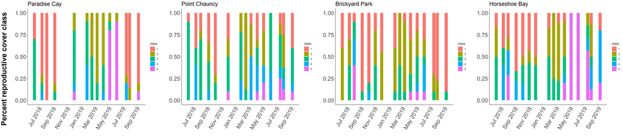

```r
a <- ggplot(hsfreq, aes(fill = class, y = Freq, x = date)) +
  geom_bar(position = "fill", stat = "identity") + ggtitle("Horseshoe Bay") +
  scale_x_date(date_breaks = "2 month", date_labels = "%b %Y") + theme(plot.title = element_text(size = 20, face = "plain")) +
  theme(
    axis.text.x = element_text(angle = 60, hjust = 1),
    axis.text = element_text(size = 20),
    axis.title = element_text(size = 20, face = "plain")
  ) + ylab(" ") + xlab(" ") + theme(
    panel.grid.major = element_blank(),
    panel.grid.minor = element_blank(),
    panel.background = element_blank(),
    axis.line = element_line(colour = "black")
  )

b <- ggplot(byfreq, aes(fill = class, y = Freq, x = date)) +
  geom_bar(position = "fill", stat = "identity") + ggtitle("Brickyard Park") +
  scale_x_date(date_breaks = "2 month", date_labels = "%b %Y") + theme(plot.title = element_text(size = 20, face = "plain")) +
  theme(
    axis.text.x = element_text(angle = 60, hjust = 1),
    axis.text = element_text(size = 20),
    axis.title = element_text(size = 20, face = "plain")
  ) + ylab(" ") + xlab(" ") + theme(
    panel.grid.major = element_blank(),
    panel.grid.minor = element_blank(),
    panel.background = element_blank(),
    axis.line = element_line(colour = "black")
  )

c <- ggplot(ndfreq, aes(fill = class, y = Freq, x = date)) +
  geom_bar(position = "fill", stat = "identity") + ggtitle("Point Chauncy") +
  scale_x_date(date_breaks = "2 month", date_labels = "%b %Y") + theme(plot.title = element_text(size =20, face = "plain")) +
  theme(
    axis.text.x = element_text(angle = 60, hjust = 1),
    axis.text = element_text(size = 20),
    axis.title = element_text(size = 20, face = "plain")
  ) + ylab(" ") + xlab(" ") + theme(
    panel.grid.major = element_blank(),
    panel.grid.minor = element_blank(),
    panel.background = element_blank(),
    axis.line = element_line(colour = "black")
  )

d <- ggplot(pcfreq, aes(fill = class, y = Freq, x = date)) +
  geom_bar(position = "fill", stat = "identity") + ggtitle("Paradise Cay") +
  scale_x_date(date_breaks = "2 month", date_labels = "%b %Y") + theme(
    axis.text.x = element_text(angle = 60, hjust = 1),
    plot.title = element_text(size = 20, face = "plain")
  ) + theme(axis.text = element_text(size = 20),
            axis.title = element_text(size = 20, face = "plain")) + ylab(" ") + xlab(" ") + theme(
              panel.grid.major = element_blank(),
              panel.grid.minor = element_blank(),
              panel.background = element_blank(),
              axis.line = element_line(colour = "black")
            )

figure <- ggarrange(d, c, b, a, ncol = 4, nrow = 1)
annotate_figure(
  figure,
  left = text_grob(
    "Percent reproductive cover class",
    color = "black",
    rot = 90,
    size = 25,
    face="bold"
  )
)
```

Greyscale: hard to tell the difference between the 5 shades of grey

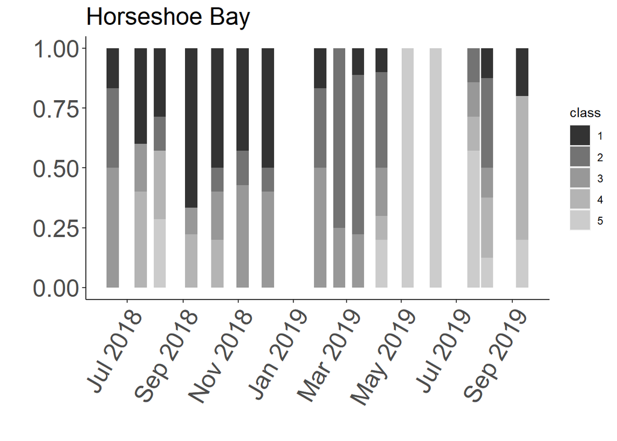

```r
hsfreq %>% ggplot(aes(fill = class, y = Freq, x = date)) +
  geom_bar(position = "fill", stat = "identity") +
  scale_fill_grey()+
  ggtitle("Horseshoe Bay") +
  scale_x_date(date_breaks = "2 month", date_labels = "%b %Y") +
  theme(
    plot.title = element_text(size = 20, face = "plain"),
    axis.text.x = element_text(angle = 60, hjust = 1),
    axis.text = element_text(size = 20),
    axis.title = element_text(size = 20, face = "plain"),
    panel.grid.major = element_blank(),
    panel.grid.minor = element_blank(),
    panel.background = element_blank(),
    axis.line = element_line(colour = "black")) +
  ylab(" ") + xlab(" ")
```

Gradient: gradient of a single color so the darker the color, the more reproductive. I like it more but it’s hard to make out the lightest color

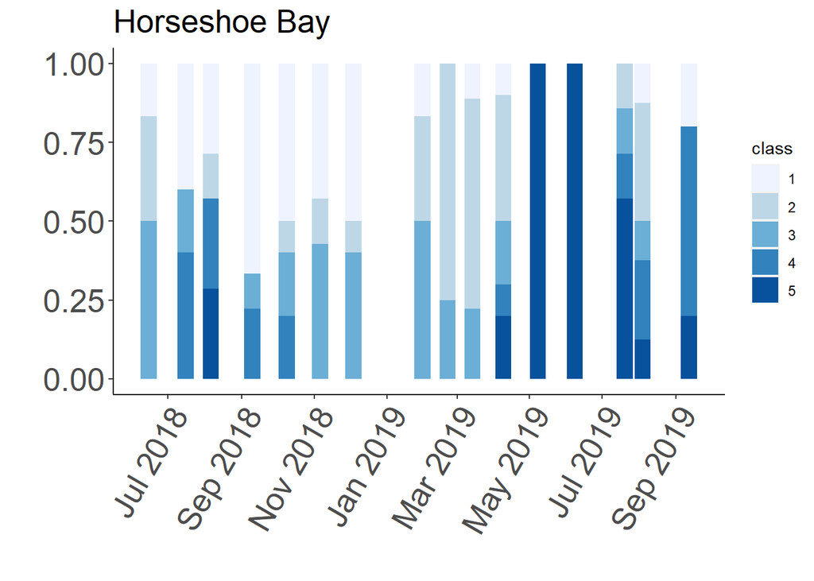

```r
hsfreq %>% ggplot(aes(fill = class, y = Freq, x = date)) +
  geom_bar(position = "fill", stat = "identity") +
  scale_fill_brewer(palette="Blues")+
  ggtitle("Horseshoe Bay") +
  scale_x_date(date_breaks = "2 month", date_labels = "%b %Y") +
  theme(
    plot.title = element_text(size = 20, face = "plain"),
    axis.text.x = element_text(angle = 60, hjust = 1),
    axis.text = element_text(size = 20),
    axis.title = element_text(size = 20, face = "plain"),
    panel.grid.major = element_blank(),
    panel.grid.minor = element_blank(),
    panel.background = element_blank(),
    axis.line = element_line(colour = "black")) +
  ylab(" ") + xlab(" ")
```

Outline bar: outlining the bar so that you can see the lightest color better

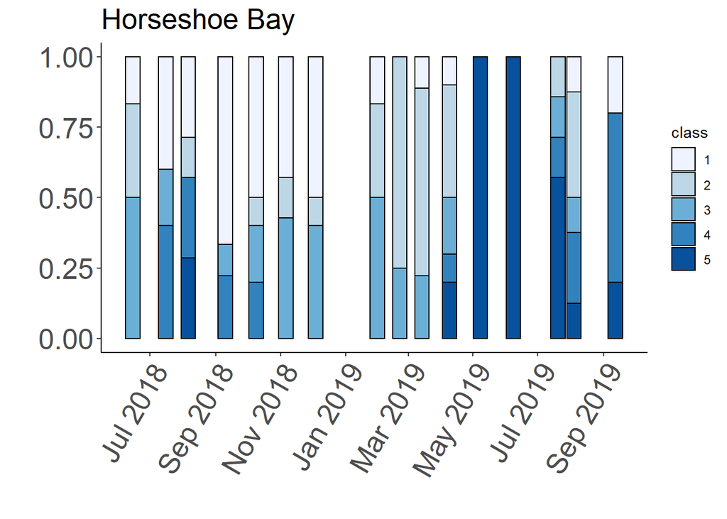

```r
hsfreq %>% ggplot(aes(fill = class, y = Freq, x = date)) +
  geom_bar(position = "fill", stat = "identity", color="black") +
  scale_fill_brewer(palette="Blues")+
  ggtitle("Horseshoe Bay") +
  scale_x_date(date_breaks = "2 month", date_labels = "%b %Y") +
  theme(
    plot.title = element_text(size = 20, face = "plain"),
    axis.text.x = element_text(angle = 60, hjust = 1),
    axis.text = element_text(size = 20),
    axis.title = element_text(size = 20, face = "plain"),
    panel.grid.major = element_blank(),
    panel.grid.minor = element_blank(),
    panel.background = element_blank(),
    axis.line = element_line(colour = "black")) +
  ylab(" ") + xlab(" ")
```

Formatting all graphs like that, changing the y-axis to percent format, adding common legend

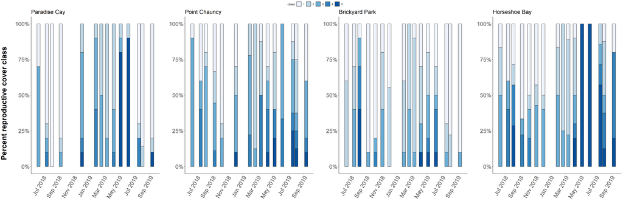

```r
a <-
  hsfreq %>% ggplot(aes(fill = class, y = Freq, x = date)) +
  geom_bar(position = "fill",
           stat = "identity",
           color = "black",
           show.legend = TRUE) +
  scale_y_continuous(labels = scales::percent)+
  scale_fill_brewer(palette = "Blues") +
  ggtitle("Horseshoe Bay") +
  scale_x_date(date_breaks = "2 month", date_labels = "%b %Y") +
  theme(
    plot.title = element_text(size = 20, face = "plain"),
    axis.text.x = element_text(angle = 60, hjust = 1),
    axis.text = element_text(size = 20),
    axis.title = element_text(size = 20, face = "plain"),
    panel.grid.major = element_blank(),
    panel.grid.minor = element_blank(),
    panel.background = element_blank(),
    axis.line = element_line(colour = "black")
  ) +
  ylab(" ") + xlab(" ")


b<-
  byfreq %>% ggplot(aes(fill = class, y = Freq, x = date)) +
  geom_bar(position = "fill",
           stat = "identity",
           color = "black",
           show.legend = TRUE) +
  scale_y_continuous(labels = scales::percent)+
  scale_fill_brewer(palette = "Blues") +
  ggtitle("Brickyard Park") +
  scale_x_date(date_breaks = "2 month", date_labels = "%b %Y") +
  theme(
    plot.title = element_text(size = 20, face = "plain"),
    axis.text.x = element_text(angle = 60, hjust = 1),
    axis.text = element_text(size = 20),
    axis.title = element_text(size = 20, face = "plain"),
    panel.grid.major = element_blank(),
    panel.grid.minor = element_blank(),
    panel.background = element_blank(),
    axis.line = element_line(colour = "black")
  ) +
  ylab(" ") + xlab(" ")

c<-
  ndfreq %>% ggplot(aes(fill = class, y = Freq, x = date)) +
  geom_bar(position = "fill",
           stat = "identity",
           color = "black",
           show.legend = TRUE) +
  scale_y_continuous(labels = scales::percent)+
  scale_fill_brewer(palette = "Blues") +
  ggtitle("Point Chauncy") +
  scale_x_date(date_breaks = "2 month", date_labels = "%b %Y") +
  theme(
    plot.title = element_text(size = 20, face = "plain"),
    axis.text.x = element_text(angle = 60, hjust = 1),
    axis.text = element_text(size = 20),
    axis.title = element_text(size = 20, face = "plain"),
    panel.grid.major = element_blank(),
    panel.grid.minor = element_blank(),
    panel.background = element_blank(),
    axis.line = element_line(colour = "black")
  ) +
  ylab(" ") + xlab(" ")

d<-
  pcfreq %>% ggplot(aes(fill = class, y = Freq, x = date)) +
  geom_bar(position = "fill",
           stat = "identity",
           color = "black",
           show.legend = TRUE) +
  scale_fill_brewer(palette = "Blues") +
  scale_y_continuous(labels = scales::percent)+
  ggtitle("Paradise Cay") +
  scale_x_date(date_breaks = "2 month", date_labels = "%b %Y") +
  theme(
    plot.title = element_text(size = 20, face = "plain"),
    axis.text.x = element_text(angle = 60, hjust = 1),
    axis.text = element_text(size = 20),
    axis.title = element_text(size = 20, face = "plain"),
    panel.grid.major = element_blank(),
    panel.grid.minor = element_blank(),
    panel.background = element_blank(),
    axis.line = element_line(colour = "black")
  ) +
  ylab(" ") + xlab(" ")


figure <- ggarrange(d, c, b, a, ncol = 4, nrow = 1, common.legend = TRUE)
annotate_figure(
  figure,
  left = text_grob(
    "Percent reproductive cover class",
    color = "black",
    rot = 90,
    size = 25,
    face="bold"
  )
)
```

Across all sites and all months there is only one survey (Paradise Cay August 2018) that is 100% the lowest repro class